# Scientific Computing — Problem Set 3

# Stefan Countryman

### *Question 1*

**1.** Determine the true means, $\hat{\bar{v}}_{a}$, for $v_{1}$, $v_{2}$, ..., $v_{5}$

```julia
include("q1/p1.jl")
```

```
~~ QUESTION 1 ~~

Part 1
	The true means v̄̂1, v̄̂2, ..., v̄̂5 are:

	v̄̂[1] = 1.7608399300642636
	v̄̂[2] = 2.886344221395922
	v̄̂[3] = 4.01184851272758
	v̄̂[4] = 5.137116475044777
	v̄̂[5] = 6.262384437361974
```

**2.** Consider values $N$ = 1,000 and $N$ = 10,000. There are $M/N$ samples of this size in our $M$ values. Histogram the sample means for these values of $N$ and determine the true standard deviation of the means $\hat{\sigma}_{\bar{v}_{a},N}$.

Recall that $\hat{\sigma}_{\bar{v}_{a},N} = \frac{\sigma}{\sqrt{N}}$, where $\sigma$ is the variance of the overall population. So we should see that $$\bigg(\frac{\hat{\sigma}_{\bar{v}_{a},N_{1}}}{\hat{\sigma}_{\bar{v}_{a},N_{2}}}\bigg)^{2} = \frac{N_{2}}{N_{2}} = 10$$ in this case. This is roughly the result we get (see below).

```julia
include("q1/p2.jl")
```

```
Part 2

	N1 = 1000
	N2 = 10000

	 Standard deviations of the sample means are:

	σ̂1 = [0.24311784337397993,0.19294412355261062,0.17705504776718253,0.1942781528615023,0.24564575367828553]
	σ̂2 = [0.08172736485350657,0.06386716663997997,0.05606668407073371,0.05900974192855537,0.07424533843618523]

	We expect (σ̂1./σ̂2).^2 = N2/N1 = 10:

	(σ̂1[1]/σ̂2[1])^2 = 8.849091320213951
	(σ̂1[2]/σ̂2[2])^2 = 9.12657468656696
	(σ̂1[3]/σ̂2[3])^2 = 9.972565157927063
	(σ̂1[4]/σ̂2[4])^2 = 10.839281637664836
	(σ̂1[5]/σ̂2[5])^2 = 10.94662245831677

	...which is pretty close.

	Making histograms and placing in 'histograms' vector
```

```julia
histograms[1]
```

[figure not shown]

```julia
histograms[2]
```

[figure not shown]

```julia
histograms[3]
```

[figure not shown]

```julia
histograms[4]
```

[figure not shown]

```julia
histograms[5]
```

[figure not shown]

### Each histogram shows visibly smaller standard deviation for the larger sample size.

**3.** You can now determine the true autocorrelation function for each variable, $\hat{C}_{v_{a}, n}$, which is given by:

$$\hat{C}_{v_{a}, n} = \frac{1}{M-n} \sum_{i=1}^{M-n} \big(v_{a,i+n} - \hat{\bar{v}}_{a}\big)\big(v_{a,i} - \hat{\bar{v}}_{a}\big)$$

$n$ goes from 0 to some maximum value $n_{cut}$ with $n_{cut} << M$. Plot $\hat{C}_{v_{a},n}/\hat{C}_{v_{a},0}$ versus $n$ for $a = 1...5$.

We want to pick our bin sizes $n$ such that $\hat{C}_{v_{a},n}$ is small.

```julia
include("q1/p3.jl");
```

```
Part 3

	Calculating autocorrelations

	Making autocorrelation plots and placing in 'plots' vector
```

```julia
plots[1]
```

[figure not shown]

```julia
plots[2]
```

[figure not shown]

```julia
plots[3]
```

[figure not shown]

```julia
plots[4]
```

[figure not shown]

```julia
plots[5]
```

[figure not shown]

**3.** Find the integrated autocorrelation times

$$ \hat{\tau}_{int,v_{a}} \equiv \frac{1}{2}\frac{1}{\hat{C}_{v_{a},0}} \sum_{n=-n_{cut}}^{n_{cut}} \hat{C}_{v_{a},n} = \sum_{n=0}^{n_{cut}} \frac{\hat{C}_{v_{a},n}}{\hat{C}_{v_{a},0}} - \frac{1}{2} $$

...since the zeroth term equals 1.

Estimate a value for $n_{cut}$ from your plots. $n_{cut}$ should be large enough that $\hat{C}_{v_{a},n}/\hat{C}_{v_{a},0}$ has gotten close enough to zero that the value of $\hat{\tau}_{int,v_{a}}$ is not affected by modest changes in $n_{cut}$.

```julia
include("q1/p4.jl")
```

```
Part 4

	Pick ncut = 200 and calculate autocorrelation times

	Autocorrelation times:

		τ̂v1:	42.02837656926044
		τ̂v2:	42.64103861292871
		τ̂v3:	39.9497824976959
		τ̂v4:	42.55317445674922
		τ̂v5:	41.84790218850918
```

**5.** Calculate the true standard deviation of the data, *i.e.*

$$ \hat{\sigma}_{v_{a}}^{2} \equiv \frac{1}{M-1} \sum_{i=1}^{M} (v_{a,i} - \hat{\bar{v}}_{a})^{2} $$

For a sample of size %N%, we should have

$$ \hat{\sigma}_{\bar{v}_{a},N} = \sqrt{\frac{2\hat{\tau}_{int,v_{a}}}{N}} \hat{\sigma}_{v_{a}} $$

Giving the testable hypothesis that

$$ N = 2 \hat{\tau}_{int,v_{a}} \frac{\hat{\sigma}_{v_{a}}^{2}}{\hat{\sigma}_{\bar{v}_{a},N}^{2}} $$

```julia
include("q1/p5.jl")
```

```
Part 5

	Calculating σ̂ for each a
		σ̂[1] = 0.8668358466567552
		σ̂[2] = 0.6795499044957977
		σ̂[3] = 0.6377090628372403
		σ̂[4] = 0.676184727622303
		σ̂[5] = 0.8618077497822448

	Recall, from Part 2:

	N1 = 1000
	N2 = 10000


	We expect:

		2 * τ̂[a] * ( σ̂[a]^2 / σ̂1[a]^2 ) = N1 = 1000

	and

		2 * τ̂[a] * ( σ̂[a]^2 / σ̂2[a]^2 ) = N2 = 10000

	Test that hypothesis...

	for N1:

		2 * τ̂[a] * ( σ̂[a]^2 / σ̂1[a]^2 ) = N1 = 1000

		2 * τ̂[a] * ( σ̂[a]^2 / σ̂1[a]^2 ) = N1 = 1000

		2 * τ̂[a] * ( σ̂[a]^2 / σ̂1[a]^2 ) = N1 = 1000

		2 * τ̂[a] * ( σ̂[a]^2 / σ̂1[a]^2 ) = N1 = 1000

		2 * τ̂[a] * ( σ̂[a]^2 / σ̂1[a]^2 ) = N1 = 1000

	...and for N2:

		2 * τ̂[a] * (  σ̂[a]^2 / σ̂2[a]^2 ) = N2 = 10000

		2 * τ̂[a] * (  σ̂[a]^2 / σ̂2[a]^2 ) = N2 = 10000

		2 * τ̂[a] * (  σ̂[a]^2 / σ̂2[a]^2 ) = N2 = 10000

		2 * τ̂[a] * (  σ̂[a]^2 / σ̂2[a]^2 ) = N2 = 10000

		2 * τ̂[a] * (  σ̂[a]^2 / σ̂2[a]^2 ) = N2 = 10000

	Which is exactly what we would expect.
```

**6.** Calculate the true covariance matrix for the data, defined by

$$ \hat{c}_{v_{a},v_{b}} = \frac{1}{M} \sum_{i=1}^{M} (v_{a,i} - \hat{\bar{v}}_{a}) (v_{b,i} - \hat{\bar{v}}_{b}) $$

It is customary to define a normalized version of $\hat{c}_{v_{a},v_{b}}$ by

$$ \hat{\rho}_{v_{a},v_{b}} \equiv \frac{\hat{c}_{v_{a},v_{b}}}{\hat{\sigma}_{v_{a}}\hat{\sigma}_{v_{b}}} $$

*Some scratch work for problem 6:*

[figure not shown]

We can nicely express the covariance matrix $\hat{c}$ as

$$ \hat{c} = \frac{1}{M} D^{T}D $$

or in code as

```
ĉ = transpose(D) * D ./ M
```

where

```
D = v - ones(M) * transpose(v̄̂)
```

and we can write $\hat{\rho}_{v_{a},v_{b}}$ as

```
  ρ̂ = ĉ ./ ( σ * transpose(σ) )
```

```julia
include("q1/p6.jl")
```

```
Part 6

	Calculating the true covariance matrix, ĉ:

	Calculating the normalized covariance matrix, ρ̂:
```

```
5x5 Array{Float64,2}:
 0.999999    0.930249  0.623271  0.293947  6.93888e-5
 0.930249    0.999999  0.866737  0.593589  0.290118
 0.623271    0.866737  0.999999  0.86551   0.618212
 0.293947    0.593589  0.86551   0.999999  0.928775
 6.93888e-5  0.290118  0.618212  0.928775  0.999999
```

### As expected, the normalized variances along the main diagonal are all 1.

```
INFO: Loading help data...
Warning: using PyPlot.plot in module Main conflicts with an existing identifier.
```

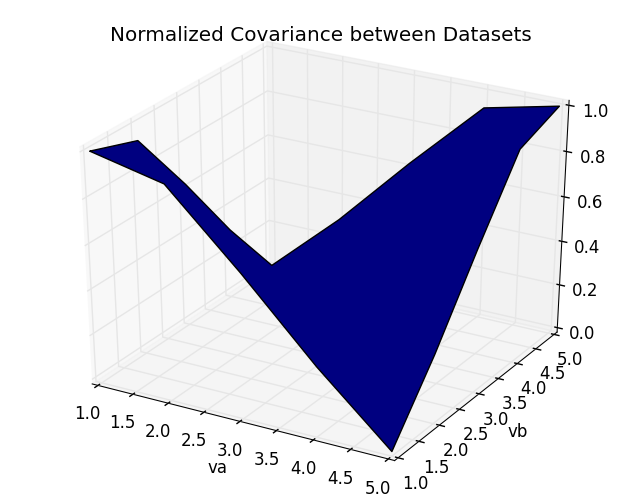

```
PyObject <matplotlib.text.Text object at 0x106816390>
```

```julia
using PyPlot
surf(ρ̂)
xlabel("va")
ylabel("vb")
title("Normalized Covariance between Datasets")
```

### I'm having trouble getting matplotlib to render the surface correctly; it looks fine from a different angle (nicely peaked along the main diagonal), but from the default angle, those polygons are transparent.

**7.** Pick two groups of data from the full universe of data. One should have N = 1,000 and the other should have N = 10,000. These two groups represent results one might get from simulations. These two groups represent results one might get from simulations. We want to see how well these groups represent reqults one might get from simulations. We want to see how well these groups reproduced the true statistical results for these data.

*a.* Estimate the autocorrelation function $C_{v_{a},n}$ from these two groups and the integrated autocorrelation time.

*b.* Use these to determine the standard deviation of the mean $\sigma_{\bar{b}_{a},N}$.

*c.* Compare this with the results from the universe of data. Also compare the normalized covariance matrix $\rho_{v_{a},v_{b}}$ from these small samples with the universe of data.

```julia
include("q1/p7.jl")
```

```
Part 7

	Pick subjets v1 and v2 of each dataset,
	sizes N1 = 1,000 & N2 = 10,000.

	Estimate autocorrelations

	...for N1...

	...for N2 (See plots below)

	Placing estimated autocorrelation plots 'plots1' and 'plots2':

	Estimating autocorrelation times τ1 and τ2

	Estimated Autocorrelation Times for N1 = 1000:

		τ̂1v1:	13.74951861957529
		τ̂1v2:	29.47940124364486
		τ̂1v3:	38.51132468998327
		τ̂1v4:	27.62735285758149
		τ̂1v5:	20.51189041276362

	Estimated Autocorrelation Times for N2 = 10000:

		τ̂2v1:	39.48025458968078
		τ̂2v2:	38.88087329474189
		τ̂2v3:	35.897918988658574
		τ̂2v4:	40.545582808139926
		τ̂2v5:	43.35857649932133

	The estimated autocorrelation times are clearly far better for the larger sample.

	Creating estimators σ1 for the standard deviation for N1 = 1000
		σ̂1[1] = 0.8296930820182362
		σ̂1[2] = 0.6526432744961868
		σ̂1[3] = 0.6498368481466311
		σ̂1[4] = 0.7476147547983175
		σ̂1[5] = 0.9688048974827577

```

[output cut: 53 more lines]

```

		σ̂2[4] / σ̂N2[4] = 0.9562631044819188

		σ̂2[5] / σ̂N2[5] = 0.8873445773241541

	For both sample sizes, these estimates are close to the true values of
	the standard deviation of the sample means, though the agreement is far
	better for the larger sample size.

	Finally, estimate the normalized covariance matrices ρ1 and ρ2.

	Estimating the covariance matrix c1 for sample size N1 = 1000
	Estimating the covariance matrix c2 for sample size N2 = 10000
	Estimating the normalized covariant matrix ρ1 for N1 = 1000
	Estimating the normalized covariant matrix ρ2 for N2 = 10000
```

```
5x5 Array{Float64,2}:
  0.9999     0.927418  0.597699  0.239972  -0.0441403
  0.927418   0.9999    0.854005  0.556006   0.262024
  0.597699   0.854005  0.9999    0.858548   0.623379
  0.239972   0.556006  0.858548  0.9999     0.935993
 -0.0441403  0.262024  0.623379  0.935993   0.9999
```

```julia
plots1[1]
```

[figure not shown]

```julia
plots1[2]
```

[figure not shown]

```julia
plots1[3]
```

[figure not shown]

```julia
plots1[4]
```

[figure not shown]

```julia
plots1[5]
```

[figure not shown]

## The autocorrelation takes too many steps (> 100) to settle down for N1 = 1,000.

```julia
plots2[1]
```

[figure not shown]

```julia
plots2[2]
```

[figure not shown]

```julia
plots2[3]
```

[figure not shown]

```julia
plots2[4]
```

[figure not shown]

```julia
plots2[5]
```

[figure not shown]

### *Let's see how good ρ1 and ρ2 were as estimates of ρ̂:*

```julia
ρratio1 = ρ̂ ./ ρ1
```

```
5x5 Array{Float64,2}:
  1.001       1.02388   1.13433   1.36584   -0.00190611
  1.02388     1.001     1.02377   1.02902    0.899816
  1.13433     1.02377   1.001     0.979191   0.890664
  1.36584     1.02902   0.979191  1.001      0.978745
 -0.00190611  0.899816  0.890664  0.978745   1.001
```

```julia
ρrelerr1 = ones(5,5) - ρratio1
```

```
5x5 Array{Float64,2}:
 -0.00100038  -0.0238777   -0.13433     -0.365844     1.00191
 -0.0238777   -0.00100038  -0.0237709   -0.0290207    0.100184
 -0.13433     -0.0237709   -0.00100038   0.0208087    0.109336
 -0.365844    -0.0290207    0.0208087   -0.00100038   0.0212547
  1.00191      0.100184     0.109336     0.0212547   -0.00100038
```

```julia
ρratio2 = ρ̂ ./ ρ2
```

```
5x5 Array{Float64,2}:
  1.0001      1.00305  1.04278   1.22492   -0.00157201
  1.00305     1.0001   1.01491   1.06759    1.10722
  1.04278     1.01491  1.0001    1.00811    0.991711
  1.22492     1.06759  1.00811   1.0001     0.992289
 -0.00157201  1.10722  0.991711  0.992289   1.0001
```

```julia
ρrelerr2 = ones(5,5) - ρratio2
```

```
5x5 Array{Float64,2}:
 -9.93849e-5  -0.00305183  -0.0427842   -0.224922     1.00157
 -0.00305183  -9.93849e-5  -0.0149082   -0.067595    -0.107222
 -0.0427842   -0.0149082   -9.93849e-5  -0.00810824   0.00828909
 -0.224922    -0.067595    -0.00810824  -9.93849e-5   0.00771136
  1.00157     -0.107222     0.00828909   0.00771136  -9.93849e-5
```

*Again, the estimates are (for the most part) significantly better for the larger sample size. Let's compare the ratio of the relative errors of the two estimators:*

```julia
ρrelerrratio = ρrelerr1 ./ ρrelerr2
```

```
5x5 Array{Float64,2}:
 10.0657    7.82406    3.1397    1.62654    1.00033
  7.82406  10.0657     1.59448   0.429332  -0.934361
  3.1397    1.59448   10.0657   -2.56637   13.1904
  1.62654   0.429332  -2.56637  10.0657     2.75628
  1.00033  -0.934361  13.1904    2.75628   10.0657
```

*Take the geometric mean of the off-diagonal rows to see how much of a reduction in error we get, on average, in going from N1 = 1,000 to N2 = 10,000.*

```julia
ρoffdiagratio = ρrelerrratio;
mn = 1
for i in [1:5]
    ρoffdiagratio[i,i] = 1.0;   # Set diagonals to 1
end
for r in ρoffdiagratio
    mn *= r;
end
mn = mn ^ (1/16);           # Off-diagonal elements
```

```
2.643593607269463
```